# Introduction to Machine Learning

With mlr3 and DALEX

Przemyslaw Biecek

3.14.2021

# 1 Load packages

```r
library("tableone")
library("DALEX")
library("partykit")
library("mlr3")
library("mlr3learners")
library("ranger")
library("mlr3tuning")
library("paradox")

set.seed(1313)
```

# 2 Conception

Define the objective.

In this example we want to create a good ranking for patients at risk. Thus we will use the AUC measure to evaluate model performance.

## 2.1 Read the data

- `covid_spring.csv` corresponds to covid mortality data from spring 2020. We will use this data for model training.
- `covid_summer.csv` corresponds to covid mortality data from summer 2020. We will use this data for model validation.

```r
covid_spring <- read.table("covid_spring.csv", sep =";", header = TRUE, stringsAsFactors = TRUE)
covid_summer <- read.table("covid_summer.csv", sep =";", header = TRUE, stringsAsFactors = TRUE)
```

## 2.2 Explore the data

```r
library("tableone")

table1 <- CreateTableOne(vars = colnames(covid_spring)[1:11],
                         data = covid_spring,
                         strata = "Death")
print(table1)
```

```
##                                    Stratified by Death
##                                     No            Yes           p      test
##   n                                  9487           513
##   Gender = Male (%)                  4554 (48.0)    271 (52.8)   0.037
##   Age (mean (SD))                   44.19 (18.32) 74.44 (13.27) <0.001
##   Cardiovascular.Diseases = Yes (%)   839 ( 8.8)    273 (53.2)  <0.001
##   Diabetes = Yes (%)                  260 ( 2.7)     78 (15.2)  <0.001
##   Neurological.Diseases = Yes (%)     127 ( 1.3)     57 (11.1)  <0.001
##   Kidney.Diseases = Yes (%)           111 ( 1.2)     62 (12.1)  <0.001
##   Cancer = Yes (%)                    158 ( 1.7)     68 (13.3)  <0.001
##   Hospitalization = Yes (%)          2344 (24.7)    481 (93.8)  <0.001
##   Fever = Yes (%)                    3314 (34.9)    335 (65.3)  <0.001
##   Cough = Yes (%)                    3062 (32.3)    253 (49.3)  <0.001
##   Weakness = Yes (%)                 2282 (24.1)    196 (38.2)  <0.001
```

## 2.3 Transform the data

Do not condition on future! Variables like `Hospitalization` or `Cough` are not good predictors, they are not known in advance.

```r
covid_spring <- covid_spring[,c("Gender", "Age", "Cardiovascular.Diseases", "Diabetes",
               "Neurological.Diseases", "Kidney.Diseases", "Cancer",
               "Death")]
```

# 3 Hello model!

In many cases, you do not need data to create a model. Just google some information about the problem.

It turns out that CDC has some decent statistics about age-related mortality.

https://www.cdc.gov/coronavirus/2019-ncov/covid-data/investigations-discovery/hospitalization-death-by-age.html

## 3.1 Create a model

```r
cdc_risk <- function(x, base_risk = 0.00003) {
  bin <- cut(x$Age, c(-Inf, 4.5, 17.5, 29.5, 39.5, 49.5, 64.5, 74.5, 84.5, Inf))
  relative_risk <- c(2, 1, 15, 45, 130, 400, 1100, 2800, 7900)[as.numeric(bin)]
  relative_risk * base_risk
}

# check it
x <- data.frame(Age = c(25,45,85))
cdc_risk(x)
```

```
## [1] 0.00045 0.00390 0.23700
```

```r
summary(cdc_risk(covid_spring))
```

```
##    Min. 1st Qu.  Median    Mean 3rd Qu.    Max.
## 0.00003 0.00135 0.00390 0.01849 0.01200 0.23700
```

```r
table(Death = covid_spring$Death,
      Prediction.above.005 = cdc_risk(covid_spring) > 0.05)
```

```
##      Prediction.above.005
## Death FALSE TRUE
##   No   8946  541
##   Yes   237  276
```

## 3.2 Wrap the model

Different models have different APIs.

But you need One API to Rule Them All!

[More info](http://ema.drwhy.ai/do-it-yourself.html#infoDALEX)

```r
library("DALEX")
model_cdc <-  DALEX::explain(cdc_risk,
                   predict_function = function(m, x) m(x),
                   data  = covid_summer,
                   y     = covid_summer$Death == "Yes",
                   type  = "classification",
                   label = "CDC")
```

```
## Preparation of a new explainer is initiated
##   -> model label       :  CDC
##   -> data              :  10000  rows  12  cols
##   -> target variable   :  10000  values
##   -> predict function  :  function(m, x) m(x)
##   -> predicted values  :  No value for predict function target column. (  default  )
##   -> model_info        :  package Model of class: function package unrecognized , ver. Unknown , task regression (  default  )
##   -> model_info        :  type set to  classification
##   -> model_info        :  Model info detected classification task but 'y' is a logical . Converted to numeric.  (  NOTE  )
##   -> predicted values  :  numerical, min =  3e-05 , mean =  0.01480215 , max =  0.237
##   -> residual function :  difference between y and yhat (  default  )
##   -> residuals         :  numerical, min =  -0.237 , mean =  0.008497847 , max =  0.99955
##   A new explainer has been created!
```

```r
predict(model_cdc, x)
```

```
## [1] 0.00045 0.00390 0.23700
```

# 4 Model performance

For AUC the `cutoff` does not matter. But we set it to get nice precision and F1.

[More info](http://ema.drwhy.ai/modelPerformance.html#modelPerformanceMethodBin)

```r
mp_cdc <- model_performance(model_cdc, cutoff = 0.1)
mp_cdc
```

```
## Measures for:  classification
## recall     : 0.2188841
## precision  : 0.2602041
## f1         : 0.2377622
## accuracy   : 0.9673
## auc        : 0.904654
##
## Residuals:
##       0%      10%      20%      30%      40%      50%      60%      70%
## -0.23700 -0.03300 -0.01200 -0.01200 -0.00390 -0.00390 -0.00135 -0.00135
##      80%      90%     100%
## -0.00045 -0.00006  0.99955
```

## 4.1 ROC

[More info](http://ema.drwhy.ai/modelPerformance.html#fig:exampleROC)

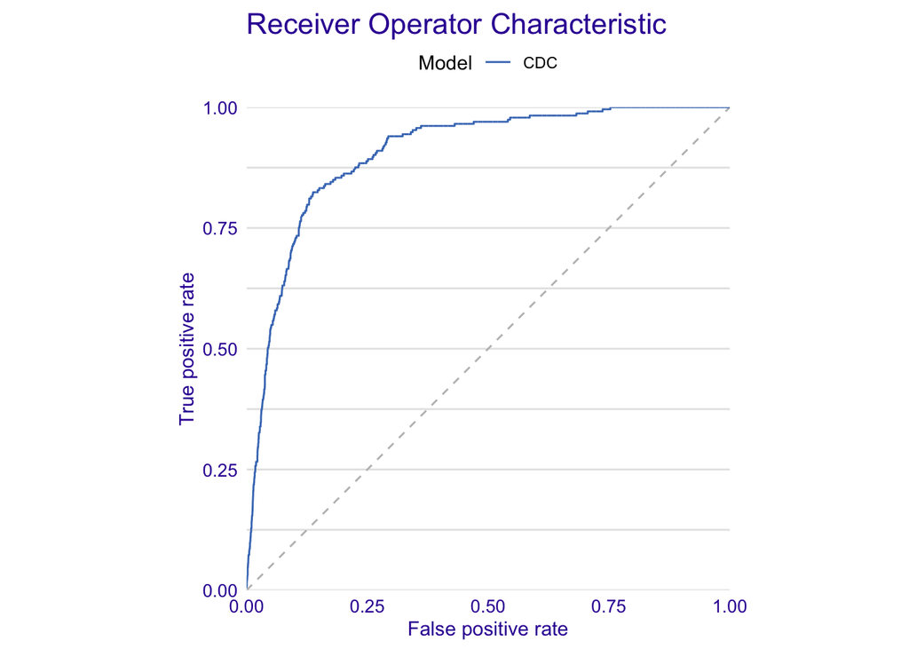

```r
plot(mp_cdc, geom = "roc")
```

## 4.2 LIFT

[More info](http://ema.drwhy.ai/modelPerformance.html#fig:examplePRC)

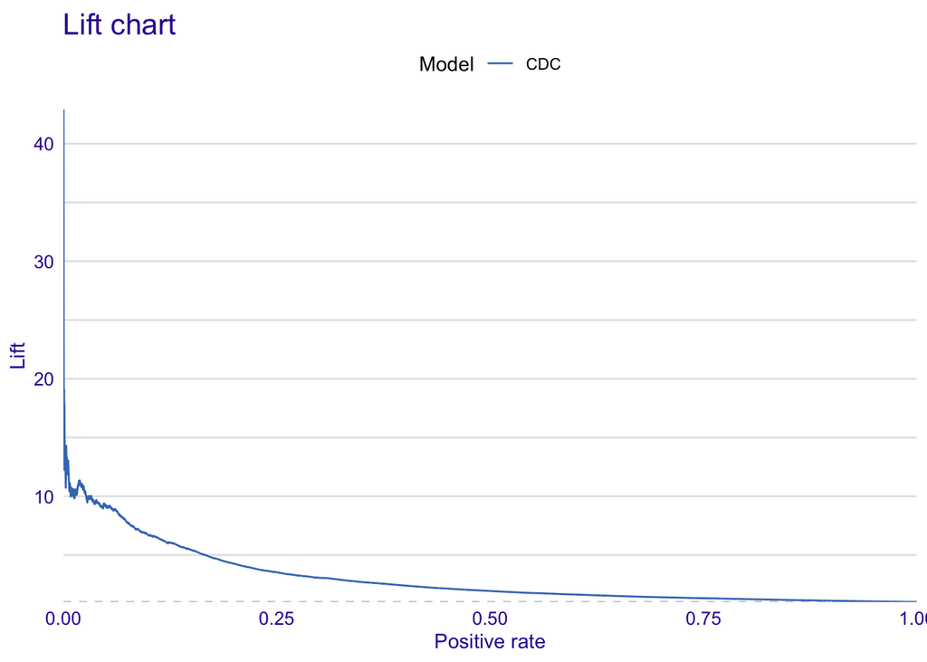

```r
plot(mp_cdc, geom = "lift")
```

## 4.3 Your turn

- Check the AUC for CDC model on the `covid_spring` data.
- Plot ROC for both `covid_spring` and `covid_summer` data.

# 5 Grow a tree

Use all the data.

[More info](https://cran.r-project.org/web/packages/partykit/vignettes/ctree.pdf)

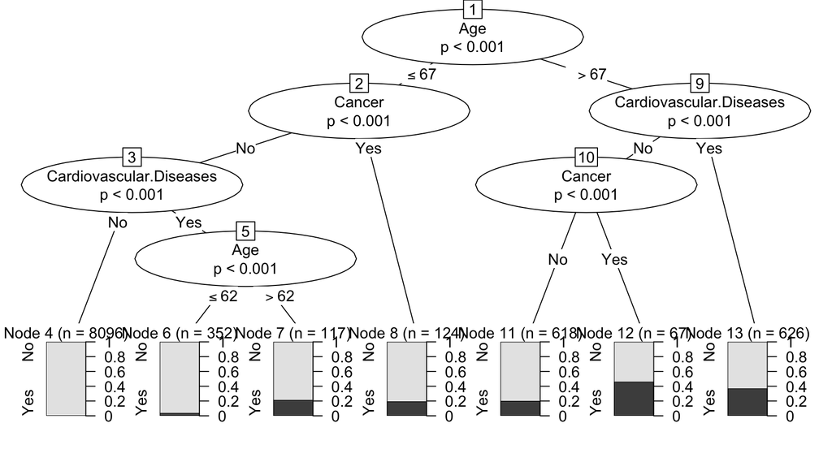

```r
library("partykit")

tree <- ctree(Death ~., covid_spring,
              control = ctree_control(alpha = 0.0001))
plot(tree)
```

```r
model_tree <-  DALEX::explain(tree,
                   predict_function = function(m, x) predict(m, x, type = "prob")[,2],
                   data = covid_summer,
                   y = covid_summer$Death == "Yes",
                   type = "classification",
                   label = "Tree",
                   verbose = FALSE)
```

## 5.1 Test your model

```r
mp_tree <- model_performance(model_tree, cutoff = 0.1)
mp_tree
```

```
## Measures for:  classification
## recall     : 0.8626609
## precision  : 0.1492205
## f1         : 0.2544304
## accuracy   : 0.8822
## auc        : 0.9136169
##
## Residuals:
##           0%          10%          20%          30%          40%          50%
## -0.462686567 -0.199029126 -0.007781621 -0.007781621 -0.007781621 -0.007781621
##          60%          70%          80%          90%         100%
## -0.007781621 -0.007781621 -0.007781621 -0.007781621  0.992218379
```

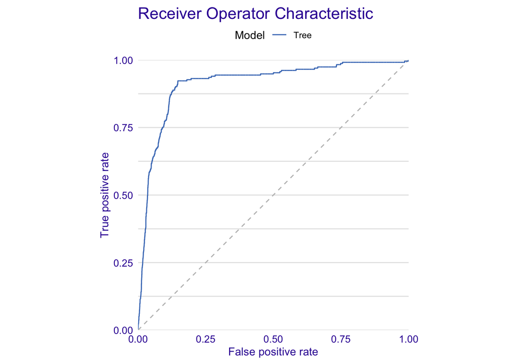

```r
plot(mp_tree, geom = "roc")
```

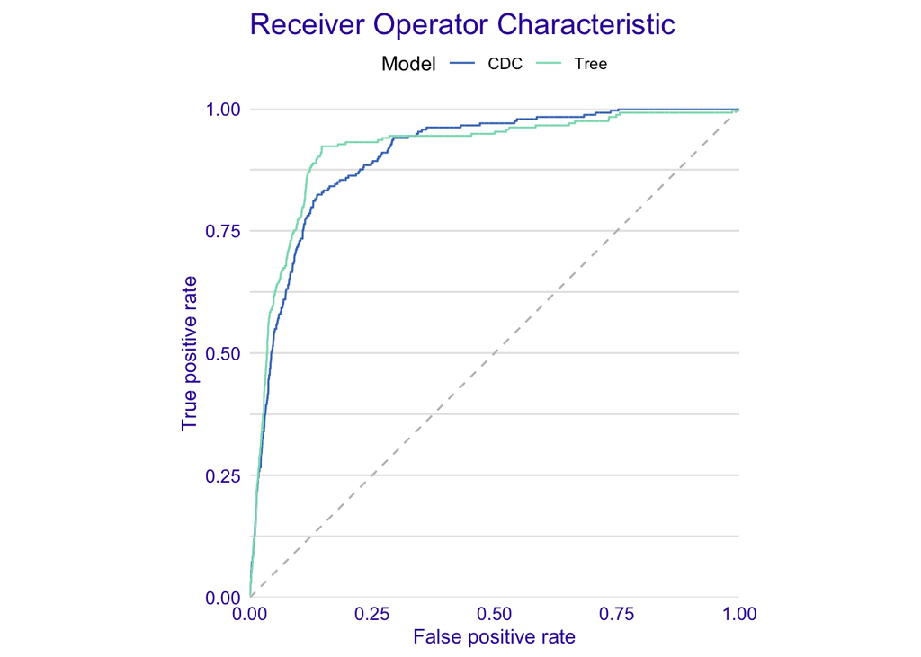

```r
plot(mp_tree, mp_cdc, geom = "roc")
```

## 5.2 Your turn

- Check the AUC for CDC model on the `covid_spring` data.
- Plot ROC for both `covid_spring` and `covid_summer` data.
- (*)Try to overfit.

# 6 Plant a forest

Let’s use `mlr3` package for this.

[More info](https://mlr3book.mlr-org.com/tasks.html)

```r
library("mlr3")

covid_task <- TaskClassif$new(id = "covid_spring",
                             backend = covid_spring,
                             target = "Death",
                             positive = "Yes")
covid_task
```

```
## <TaskClassif:covid_spring> (10000 x 8)
## * Target: Death
## * Properties: twoclass
## * Features (7):
##   - fct (6): Cancer, Cardiovascular.Diseases, Diabetes, Gender,
##     Kidney.Diseases, Neurological.Diseases
##   - int (1): Age
```

[More info](https://mlr3book.mlr-org.com/learners.html)

```r
library("mlr3learners")
library("ranger")

covid_ranger <- lrn("classif.ranger", predict_type = "prob",
                num.trees = 25)
covid_ranger
```

```
## <LearnerClassifRanger:classif.ranger>
## * Model: -
## * Parameters: num.trees=25
## * Packages: ranger
## * Predict Type: prob
## * Feature types: logical, integer, numeric, character, factor, ordered
## * Properties: importance, multiclass, oob_error, twoclass, weights
```

```r
covid_ranger$train(covid_task)
```

## 6.1 Test your model

```r
model_ranger <-  explain(covid_ranger,
                           predict_function = function(m,x)
                                predict(m, x, predict_type = "prob")[,1],
                           data = covid_summer,
                           y = covid_summer$Death == "Yes",
                           type = "classification",
                           label = "Ranger",
                           verbose = FALSE)

mp_ranger <- model_performance(model_ranger)
mp_ranger
```

```
## Measures for:  classification
## recall     : 0.111588
## precision  : 0.4482759
## f1         : 0.1786942
## accuracy   : 0.9761
## auc        : 0.9425837
##
## Residuals:
##           0%          10%          20%          30%          40%          50%
## -0.633536505 -0.129990764 -0.018303930 -0.011174022 -0.011142358 -0.011065548
##          60%          70%          80%          90%         100%
## -0.009678616 -0.007173015 -0.007121335 -0.007089671  0.992878665
```

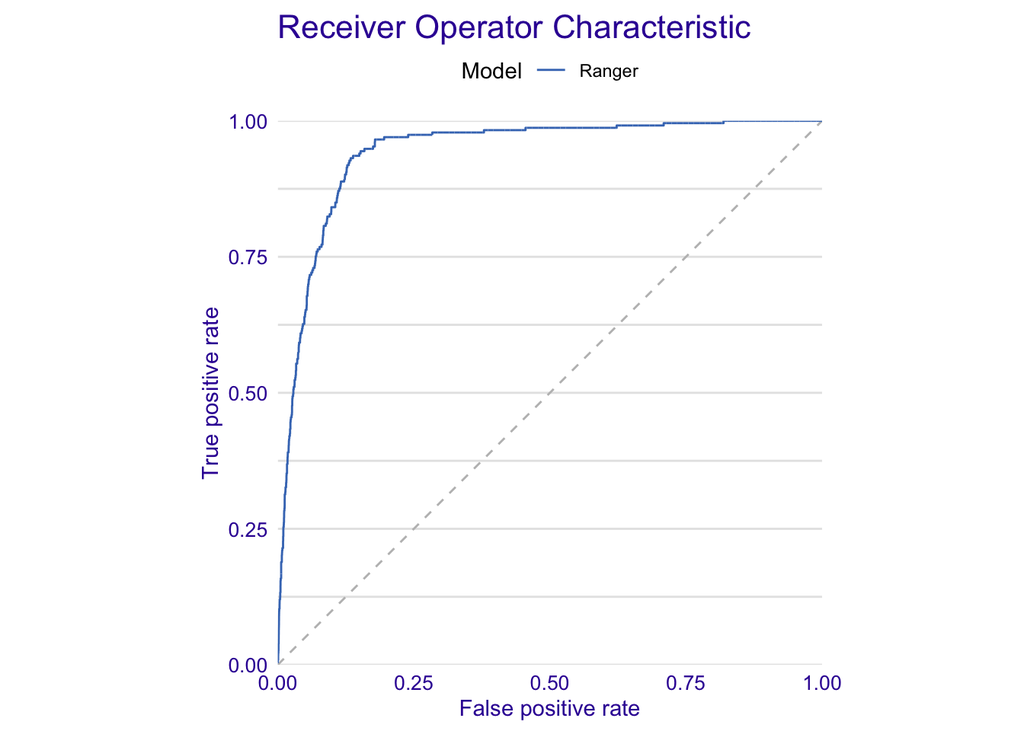

```r
plot(mp_ranger, geom = "roc")
```

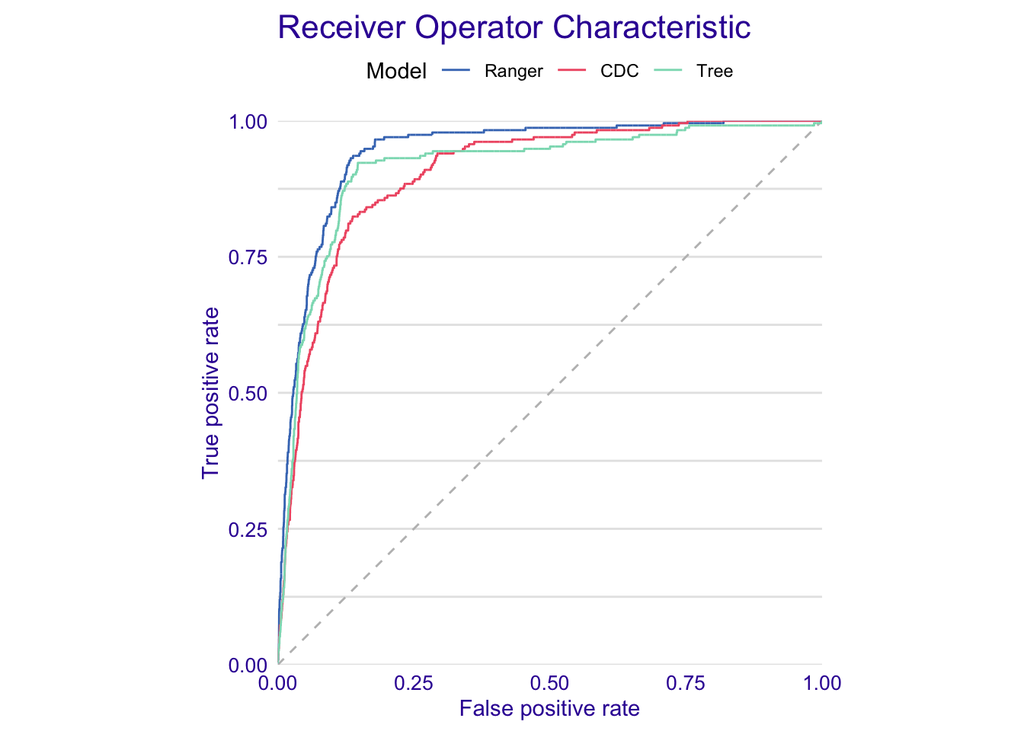

```r
plot(mp_ranger, mp_tree, mp_cdc, geom = "roc")
```

## 6.2 Your turn

- Check the AUC for Ranger model on the `covid_spring` data.
- Plot ROC for both `covid_spring` and `covid_summer` data.

# 7 Automated Hyperparameter Optimisation

## 7.1 Define the search space

[More info](https://mlr3book.mlr-org.com/searchspace.html)

```r
library("mlr3tuning")
library("paradox")

search_space = ps(
  num.trees = p_int(lower = 50, upper = 500),
  max.depth = p_int(lower = 1, upper = 10),
  minprop = p_dbl(lower = 0.01, upper = 0.1),
  splitrule = p_fct(levels = c("gini", "extratrees"))
)
search_space
```

```
## <ParamSet>
##           id    class lower upper          levels        default value
## 1: num.trees ParamInt 50.00 500.0                 <NoDefault[3]>
## 2: max.depth ParamInt  1.00  10.0                 <NoDefault[3]>
## 3:   minprop ParamDbl  0.01   0.1                 <NoDefault[3]>
## 4: splitrule ParamFct    NA    NA gini,extratrees <NoDefault[3]>
```

## 7.2 Set-up the tuner

Popular searching strategies are `random_search` and `grid_search`. Termination is set fo a specific number of evaluations. Internal testing is based on 5-fold CV.

[More info](https://mlr3book.mlr-org.com/tuning.html#autotuner)

```r
tuned_ranger = AutoTuner$new(
  learner    = covid_ranger,
  resampling = rsmp("cv", folds = 5),
  measure    = msr("classif.auc"),
  search_space = search_space,
  terminator = trm("evals", n_evals = 10),
  tuner    = tnr("random_search")
)
tuned_ranger
```

```
## <AutoTuner:classif.ranger.tuned>
## * Model: -
## * Parameters: list()
## * Packages: ranger
## * Predict Type: prob
## * Feature types: logical, integer, numeric, character, factor, ordered
## * Properties: importance, multiclass, oob_error, twoclass, weights
```

## 7.3 Tune

```r
tuned_ranger$train(covid_task)
```

```r
tuned_ranger$tuning_result
```

```
##    num.trees max.depth    minprop splitrule learner_param_vals  x_domain
## 1:       264         9 0.06907318      gini          <list[4]> <list[4]>
##    classif.auc
## 1:   0.9272979
```

```r
tuned_ranger$predict_newdata(newdata = covid_spring)$prob[1:4,]
```

```
##              Yes        No
## [1,] 0.009092137 0.9909079
## [2,] 0.009700991 0.9902990
## [3,] 0.009164498 0.9908355
## [4,] 0.009164498 0.9908355
```

## 7.4 Test your model

```r
model_tuned <-  explain(tuned_ranger,
                           predict_function = function(m,x)
                               m$predict_newdata(newdata = x)$prob[,1],
                           data = covid_summer,
                           y = covid_summer$Death == "Yes",
                           type = "classification",
                           label = "AutoTune",
                           verbose = FALSE)

mp_tuned <- model_performance(model_tuned)
mp_tuned
```

```
## Measures for:  classification
## recall     : 0.05150215
## precision  : 0.4285714
## f1         : 0.09195402
## accuracy   : 0.9763
## auc        : 0.9447171
##
## Residuals:
##           0%          10%          20%          30%          40%          50%
## -0.592588661 -0.127894604 -0.022977442 -0.009700991 -0.009164498 -0.008951611
##          60%          70%          80%          90%         100%
## -0.008855070 -0.007352912 -0.007157637 -0.007001973  0.992859130
```

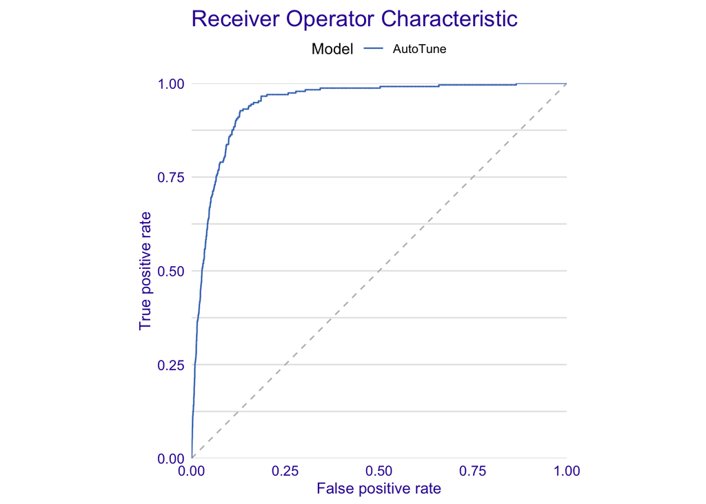

```r
plot(mp_tuned, geom = "roc")
```

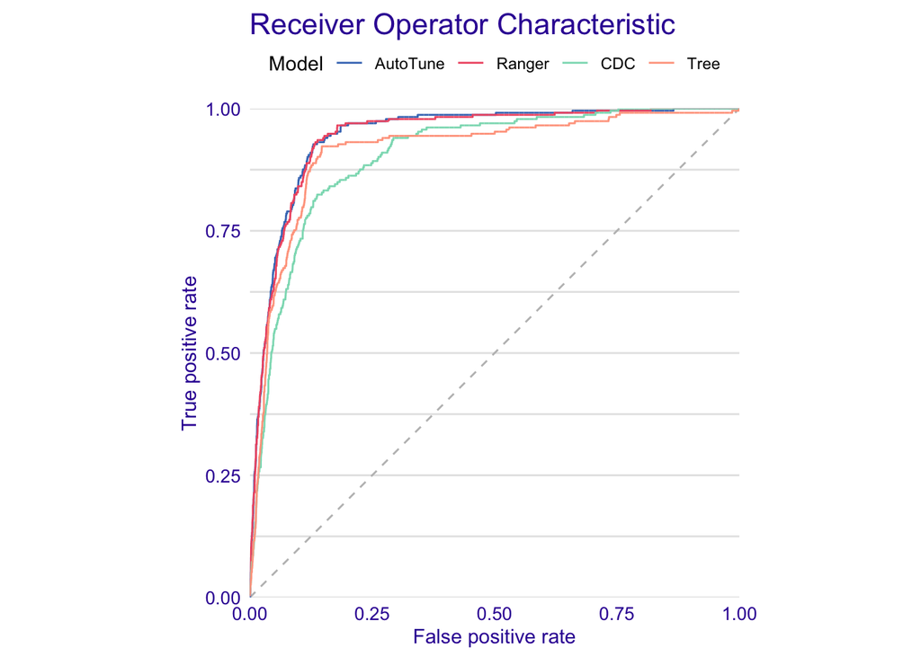

```r
plot(mp_ranger, mp_tree, mp_cdc, mp_tuned, geom = "roc")
```

## 7.5 Sum up

```r
do.call(rbind,
        list(cdc   = mp_cdc$measures,
            tree   = mp_tree$measures,
            ranger = mp_ranger$measures,
            tuned  = mp_tuned$measures))
```

```
##        recall     precision f1         accuracy auc
## cdc    0.2188841  0.2602041 0.2377622  0.9673   0.904654
## tree   0.8626609  0.1492205 0.2544304  0.8822   0.9136169
## ranger 0.111588   0.4482759 0.1786942  0.9761   0.9425837
## tuned  0.05150215 0.4285714 0.09195402 0.9763   0.9447171
```

## 7.6 Your turn

- Check the AUC for AutoTune model on the `covid_spring` data.
- Plot ROC for both `covid_spring` and `covid_summer` data.

# 8 Global level explanation

[More info](http://ema.drwhy.ai/modelLevelExploration.html)

## 8.1 Model parts

[More info](http://ema.drwhy.ai/featureImportance.html)

```r
mpart_ranger <- model_parts(model_ranger)
mpart_ranger
```

```
##                   variable mean_dropout_loss  label
## 1             _full_model_        0.06157367 Ranger
## 2                   Gender        0.06003873 Ranger
## 3          Hospitalization        0.06157367 Ranger
## 4                    Fever        0.06157367 Ranger
## 5                    Cough        0.06157367 Ranger
## 6                 Weakness        0.06157367 Ranger
## 7                    Death        0.06157367 Ranger
## 8    Neurological.Diseases        0.06220062 Ranger
## 9          Kidney.Diseases        0.06593756 Ranger
## 10                  Cancer        0.06761244 Ranger
## 11                Diabetes        0.07086397 Ranger
## 12 Cardiovascular.Diseases        0.07436361 Ranger
## 13                     Age        0.19612848 Ranger
## 14              _baseline_        0.50107019 Ranger
```

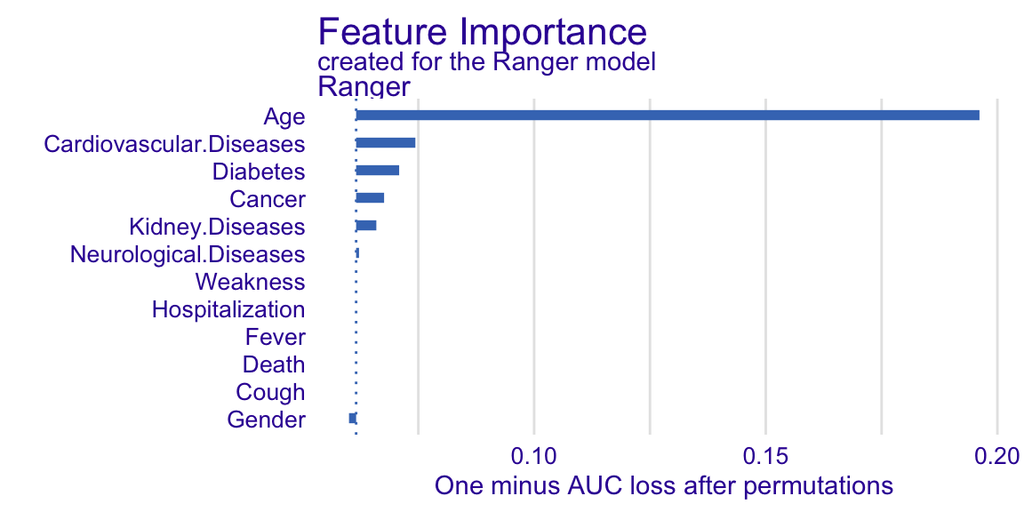

```r
plot(mpart_ranger, show_boxplots = FALSE, bar_width=2)
```

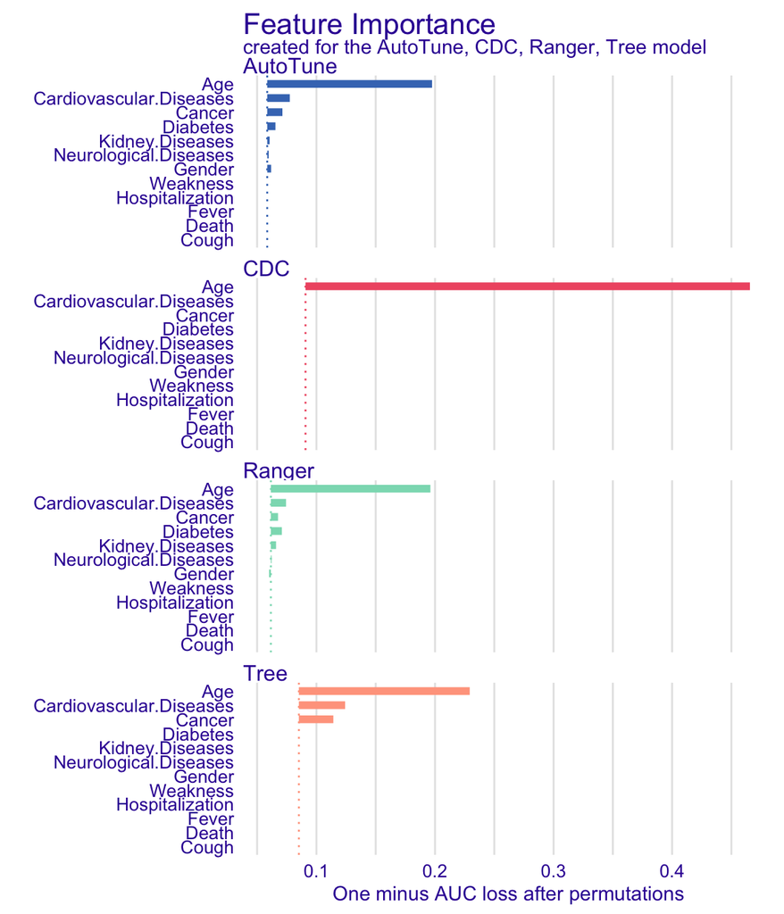

```r
mpart_cdc <- model_parts(model_cdc)
mpart_tree <- model_parts(model_tree)
mpart_tuned <- model_parts(model_tuned)

plot(mpart_cdc, mpart_tree, mpart_ranger, mpart_tuned, show_boxplots = FALSE, bar_width=2)
```

## 8.2 Your turn

- Compare with results on the `covid_spring` data.

## 8.3 Model profile

[More info](http://ema.drwhy.ai/partialDependenceProfiles.html)

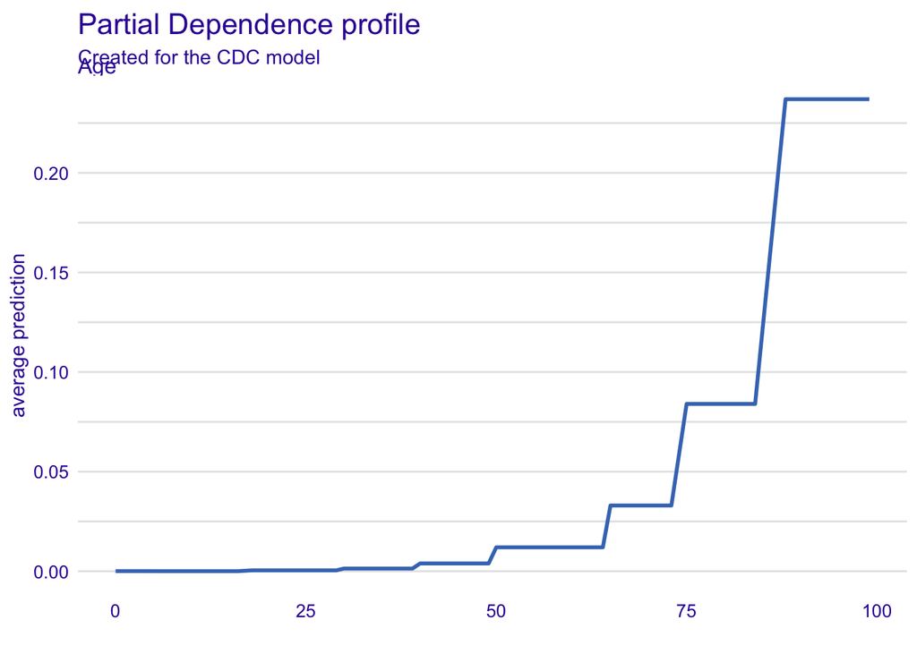

```r
mprof_cdc <- model_profile(model_cdc, "Age")
plot(mprof_cdc)
```

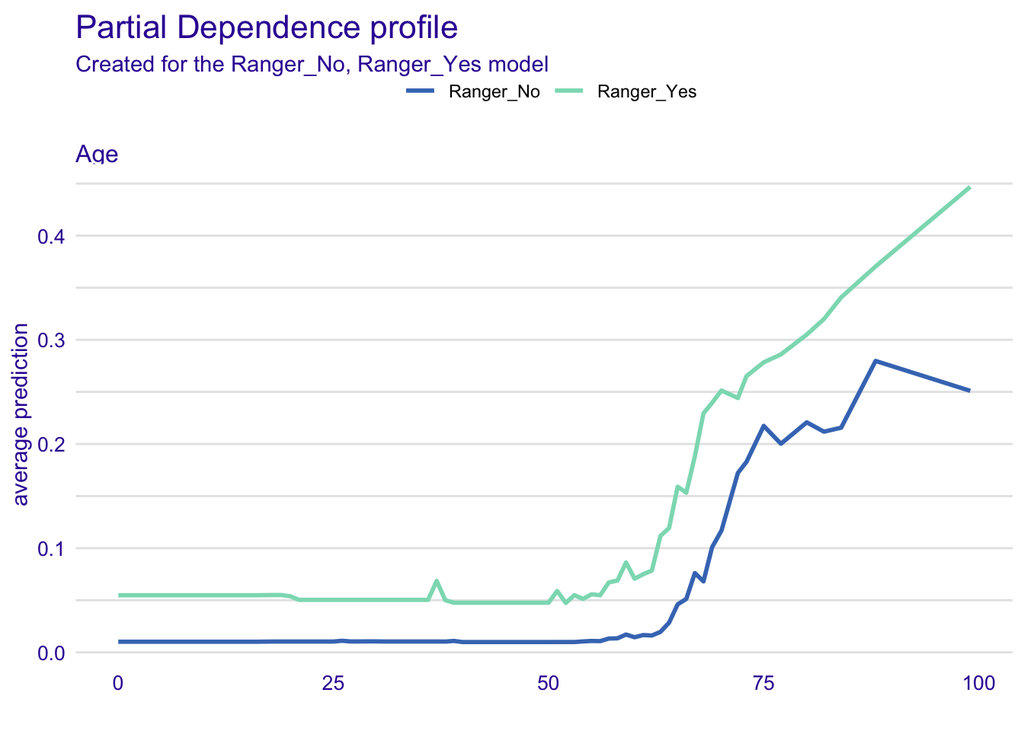

```r
mgroup_ranger <- model_profile(model_ranger, "Age", groups = "Cardiovascular.Diseases")
plot(mgroup_ranger)
```

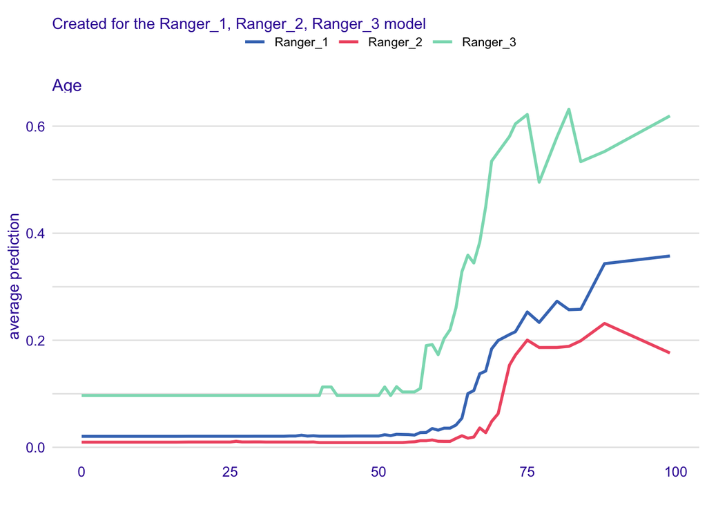

```r
mgroup_ranger <- model_profile(model_ranger, "Age", k = 3, center = TRUE)
plot(mgroup_ranger)
```

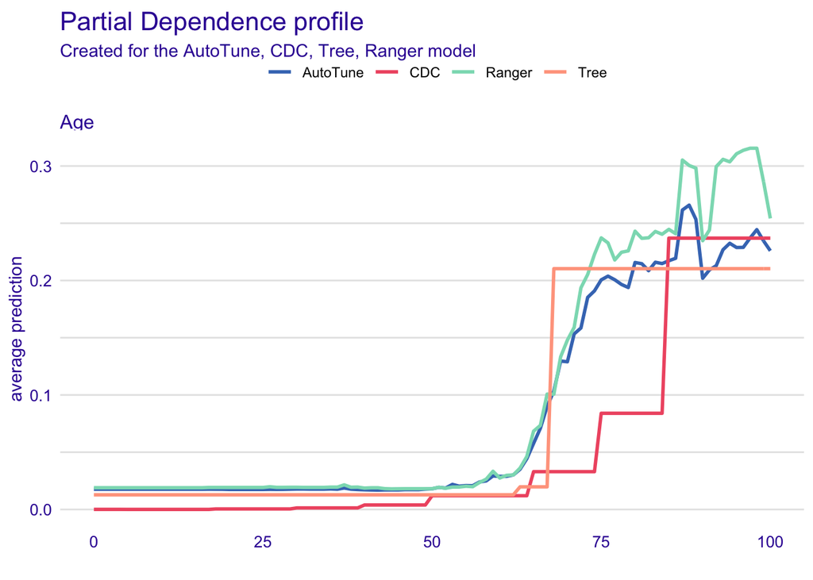

```r
mprof_cdc <- model_profile(model_cdc, variable_splits = list(Age=0:100))
mprof_tree <- model_profile(model_tree, variable_splits = list(Age=0:100))
mprof_ranger <- model_profile(model_ranger, variable_splits = list(Age=0:100))
mprof_tuned <- model_profile(model_tuned, variable_splits = list(Age=0:100))

plot(mprof_tuned, mprof_cdc, mprof_tree, mprof_ranger)
```

## 8.4 Your turn

- Compare with results on the `covid_spring` data.

# 9 Local level explanation

[More info](http://ema.drwhy.ai/InstanceLevelExploration.html)

```r
john <- data.frame(Gender = factor("Male", levels = c("Male", "Female")),
                   Age = 76,
                   Cardiovascular.Diseases = factor("Yes", levels = c("Yes", "No")),
                   Diabetes = factor("No", levels = c("Yes", "No")),
                   Neurological.Diseases = factor("No", levels = c("Yes", "No")),
                   Kidney.Diseases = factor("No", levels = c("Yes", "No")),
                   Cancer = factor("No", levels = c("Yes", "No")))
john
```

```
##   Gender Age Cardiovascular.Diseases Diabetes Neurological.Diseases
## 1   Male  76                     Yes       No                    No
##   Kidney.Diseases Cancer
## 1              No     No
```

## 9.1 Predict parts

[More info](http://ema.drwhy.ai/shapley.html)

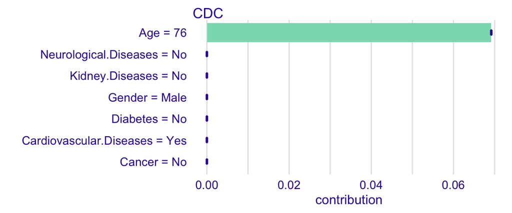

```r
ppart_cdc <- predict_parts(model_cdc, john, type = "shap")
plot(ppart_cdc)
```

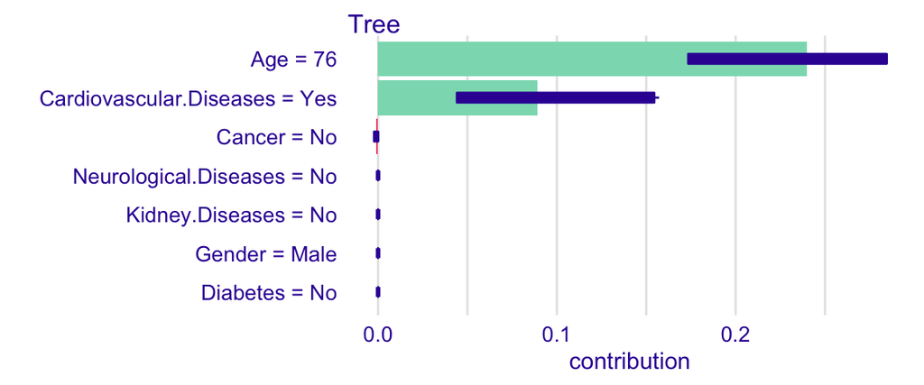

```r
ppart_tree <- predict_parts(model_tree, john, type = "shap")
plot(ppart_tree)
```

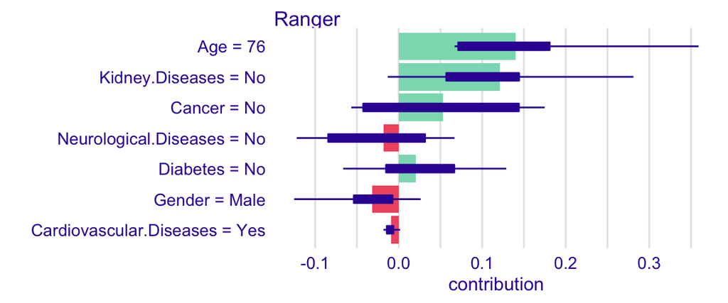

```r
ppart_ranger <- predict_parts(model_ranger, john, type = "shap")
plot(ppart_ranger)
```

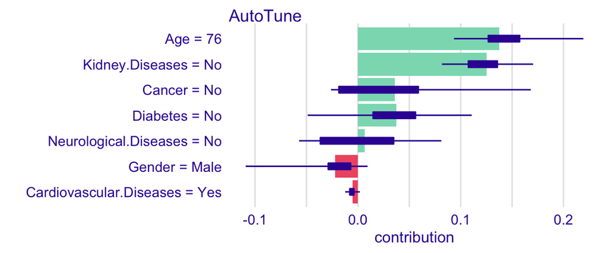

```r
ppart_tuned <- predict_parts(model_tuned, john, type = "shap")
plot(ppart_tuned)
```

## 9.2 Predict profile

[More info](http://ema.drwhy.ai/ceterisParibus.html)

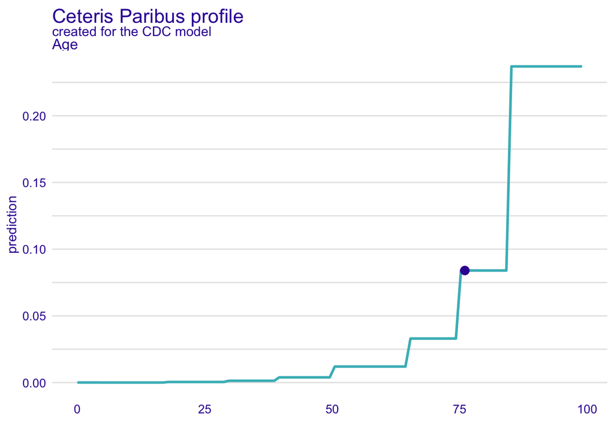

```r
mprof_cdc <- predict_profile(model_cdc, john, "Age")
plot(mprof_cdc)
```

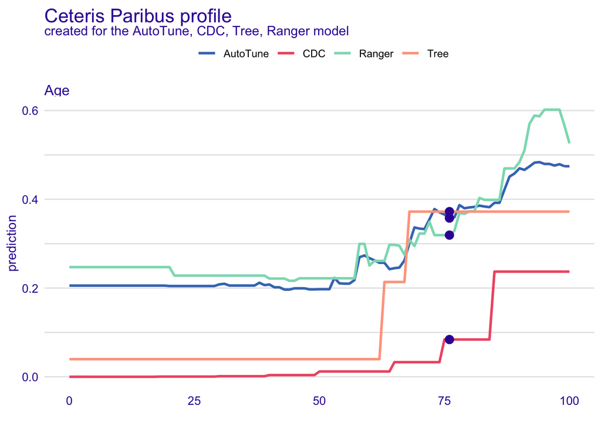

```r
mprof_cdc <- predict_profile(model_cdc, variable_splits = list(Age=0:100), john)
mprof_tree <- predict_profile(model_tree, variable_splits = list(Age=0:100), john)
mprof_ranger <- predict_profile(model_ranger, variable_splits = list(Age=0:100), john)
mprof_tuned <- predict_profile(model_tuned, variable_splits = list(Age=0:100), john)

plot(mprof_tuned, mprof_cdc, mprof_tree, mprof_ranger)
```

# 10 Extras

Play with your model!

[More info](https://github.com/ModelOriented/modelStudio/blob/master/README.md)

```r
library("modelStudio")

ms <- modelStudio(model_ranger)
ms
```